# Fields – Basics

## Aims of this section

At the end of this section you should be able to

- Describe the concept of a field
- State the link between potential and fields and calculate field strength from potentials.
- Sketch electric field lines for distributions of charges.

## What is a field?

*Recommended reading:* Tipler & Mosca 4.2, 21-4

A field is a region of space, where property of that space is characterized by either a number (a scalar field) or by three numbers (a vector field).

The concept of a field circumvents the problem of action at a distance where one inanimate object is “aware" that another has arrived.

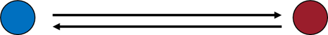

image

We understand that the first body sets up a field and the second body interacts with the first via this field. There is no need for action at a distance because the field of the 1st object is present in space whether or not the second object is there.

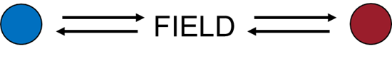

image

### Charges

Why does object 1 set up a field? Fields arise when objects have charge. Electric charges cause electromagnetic fields, but other fields arise from different types of charge for example gravitational fields arise from mass. (And the strong field that is responsible for holding quarks inside protons and neutrons arises from the colour charge – see Inside The Atom.)

There are two types of **electric charge**, $+$ and $-$. “Like" charges repel, while”unlike" charges attract. Electric charge is quantized: the **elementary charge** is $1.6021773 \times 10^{-19}$ C and is the charge on the electron and the proton. Charges measured in laboratories are always multiples of this but the quarks inside protons and neutrons and other hadrons have charges that fractions of this elementary charge. Charge is conserved in all interactions we have observed. Most everyday objects are electrically neutral with the number of protons and electrons balanced, which hides the fact that they contain enormous amounts of $+$ and $-$ charge. Things that we would describe as “charged objects", have a small imbalance in charge.

**Gravitational charge:** there is one type of gravitational charge, which is mass/energy. Gravitational charges attract. We don’t know about quantization of mass. (You can probably spend many hours on the internet reading different opinions on this). Mass/Energy is conserved and all everyday objects are gravitationally charged so they all attract each other but gravity is very weak – we can easily pick up bits of paper with an electrically charged rod when rather few electrons have been moved.

**Strong field charge:** there are three types of fundamental strong charge (red, green and blue) + three anticharges. Charges attract. Colour is quantised and colour is conserved in interactions. All everyday objects are colour neutral. Colour fields are confined within subatomic particles i.e. to length scales of $\sim 10^{-15}$ m.

## Scalar and vector fields

A scalar field is characterized at each point by a single number. e.g. the temperature, $T$, at each position in a block of metal heated at some places and cooled at others.

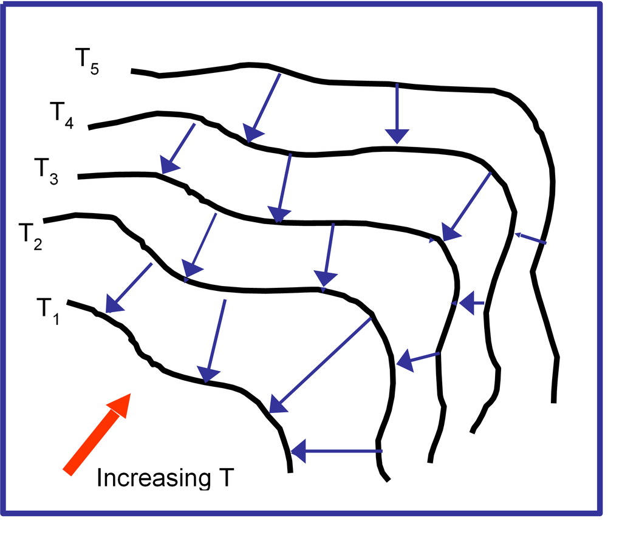

image

$T$ is a function of position i.e. $T = T(x,y,z)$. At every point we can measure the scalar value of the temperature $T$. The black lines represent isotherms i.e. lines where the temperature is constant ($T_1 < T_2 < T_3 < T_4 < T_5$). Heat flow (blue arrows) is perpendicular to the contours of constant temperature - the isotherms ($T_1$, $T_2$ etc). The magnitude of the heat flow is proportional to the temperature gradient so that the heat flow is larger when isotherms are closer together.

The scalar temperature field has an associated vector field because at any point, the heat flow is a vector, the **magnitude** and **direction** of which depend on position. Heat flow is therefore a vector field which is related to the scalar field of temperature. The vector gradient of the field of heat flow depends on the temperature at each point.

## Link between scalar and vector field

*Recommended reading:* Tipler & Mosca 23-3.

For the scalar temperature field $T(x,y,z)$ the vector describing the direction and the magnitude of the maximum temperature gradient is:

$$\begin{aligned}
\text{Grad} \; T = \nabla T = \frac{\partial T} {\partial x} \hat{\i} +
\frac{\partial T}{\partial y} \hat{\j} + \frac{\partial T}{\partial y}
\hat{\k}
\end{aligned}$$

The heat flow is a vector given by $\Q = -k \nabla T$; the minus sign is because heat flows from high temperature to low temperature.

In general, for a scalar potential $-\nabla \phi = \frac{\partial \phi} {\partial x} \hat{\i} + \frac{\partial \phi}{\partial y} \hat{\j} + \frac{\partial \phi}{\partial y} \hat{\k}$ describes the magnitude and direction of the physical effects of the potential, with an appropriate constant if needed. In the case of the electric field if the electric potential is $V$ then the vector field $\E = -\nabla V$.

As an example, the gravitational field can be obtained from the gravitational potential. The scalar gravitational potential energy is given by $U = mgz$ near the Earth’s surface, where $z$ is the height. The gravitational potential is $U/m = gz$. The gravitational field is $-\nabla(gz)=-g \hat{\k}$.

### Other operations on vectors

The vector operator $\nabla$ behaves as a vector. We have looked at grad $\nabla\phi$ where $\phi$ is a scalar field. In Maxwell’s equations, which you cover next year, you will also meet $\nabla$ operating on the electric field $\E$:

$\nabla \cdot \E$ (div or divergence)

$\nabla \times \E$ (curl or rotation)

Maxwell’s equations are one of the great achievements of 19th century Physics. They link the phenomena of electricity and magnetism and can be used to derive an expression for the speed of light. Einstein said that the theory of Relativity was rooted in Maxwell’s equations. The equations in their differential form are shown below and we will meet most of the concepts in this course and integral versions of some of the laws. You can read more about Maxwell’s Equations in Chapter 30 of Tipler and Mosca.

$$\begin{aligned}
\nabla \cdot \E &= \frac{\rho}{\epsilon_0} \\
\nabla \times \E &= - \frac{\partial \B}{\partial t} \\
\nabla \cdot \B &= 0 \\
\nabla \times \B &= \frac{\j}{c^2 \epsilon_0} + \frac{1}{c^2}
\frac{\partial \E}{\partial t}
\end{aligned}$$

Source: http://www.clerkmaxwellfoundation.org/html/about_maxwell.html ; https://maxwells-equations.com/

## Representing the electric field

*Recommended reading:* Tipler & Mosca 21-5.

The vector electric field, $\E$, at a particular point in space, associated with a collection of charges, is defined in terms of the force, $\F$, exerted on a positive test charge, $q_0$, at that point $E = F/q_0$.

$\E$ has units of Vm$^{-1}$ or NC$^{-1}$. The electric field is normally represented by field lines that indicate what a positive test charge will do. The arrows indicate the direction of the field and the density of lines indicates the strength of the field at a point. The diagram shows the electric field lines for two positive point charges of the same magnitude.

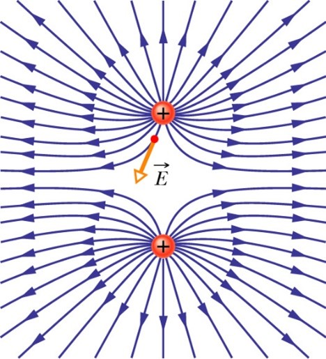

image

Note that the field lines are symmetric as they leave the charges. They do not cross.

## Equipotential surfaces

An equipotential surface is the surface of constant potential. The electric field is always perpendicular to the equipotential surface as the heat flow was always perpendicular to the isotherms in the temperature example. The picture shows an example of the equipotentials for a point charge. The field lines are in blue and the equipotentials the dashed black lines. The following website - http://www.falstad.com/emstatic/index.html - allows you to set up different charge configurations and see the field lines and equipotentials.

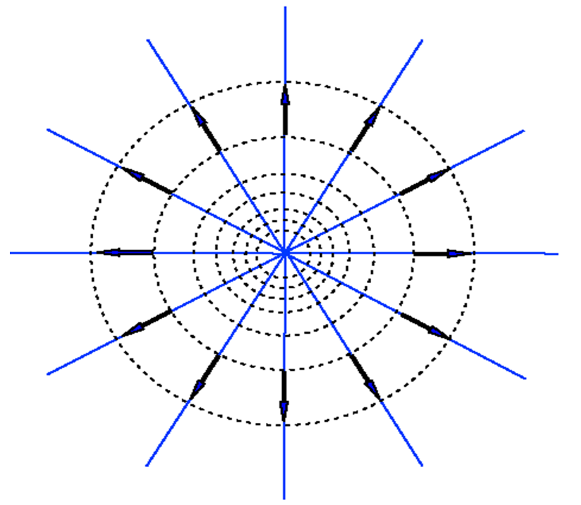

image

## Summary

- Fields arise from charges, and not just electric charges.
- A scalar potential $\Phi$ has an associated vector field $-\nabla \Phi$ and the direction of the vector field is perpendicular to the equipotentials.
- We represent fields with lines that show the direction of motion of a charge with the density of the field lines indicating the field strength.

# Electric Fields

*Recommended reading:* Tipler & Mosca Chapters 21,22,23 and some of 24 (please note that we are not covering dielectrics).

## Coulomb’s Law

*Recommended reading:* Tipler & Mosca 21-3

Coulomb’s Law gives the magnitude and direction of the forces between charges.

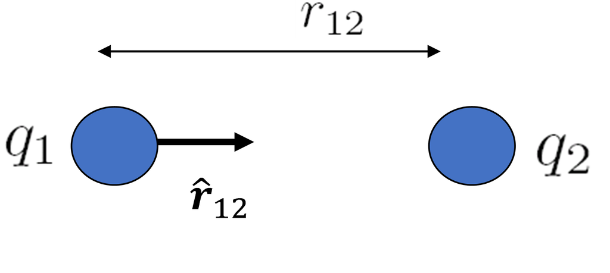

image

The force on $q_2$ due to $q_1$ is given by:

$$\label{eq:coulomb}
\F_{12}= \frac{1}{4\pi \epsilon_0} \frac{q_1 q_2}{r_{12}^2}
\hat{\r}_{12}$$

The force on $q_2$ is directed **away from** $q_1$ if $q_1 q_2$ is positive (i.e. when the charges have the same sign - like charges repel). If $q_1 q_2$ is negative (charges have different signs), the force on $q_2$ is directed **towards** $q_1$ (unlike charges attract).

## The electric field

The electric field ($\E$) is defined in terms of the force on a test charge $q_0$. The force on $q_0$ due to another charge $q$ is

$$\begin{aligned}
\F = \frac{1}{4\pi \epsilon_0} \frac{q q_0}{r_{12}^2} \hat{\r}_{12}
\end{aligned}$$

The electric field is the force divided by the magnitude of the test charge – the field is independent of the charge used to test it.

$$\begin{aligned}
\E = \frac{\F}{q_0} = \frac{1}{4\pi \epsilon_0} \frac{q q_0}{r_{12}^2}
\hat{\r}_{12}
\end{aligned}$$

## Principle of superposition

What if there are several charges?

Have a look at the diagram below:

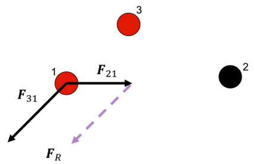

image

The principle of superposition says that the **resultant force** $\F_R$ on charge 1 due to charge 2 and charge 3 is simply the vector sum of the forces due to the individual charges.

The principle of superposition can be used to calculate the electric field $\E$ for a group of charges by summing the fields due to all charges present.

$$\begin{aligned}
\E = \E_1 + \E_2 + \E_3 + ... = \sum_i \E_i
\end{aligned}$$

## Electric dipole field

*Recommended reading:* Tipler & Mosca 21-4

An electric dipole is a combination of a positive and negative charge, equal in magnitude, a small distance from each other. The field for an electric dipole can be calculated by summing the field due to the two charges.

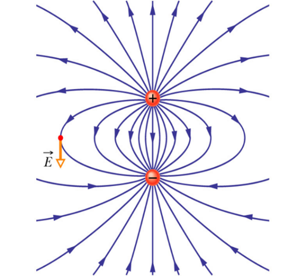

image

Consider the diagram of the dipole below:

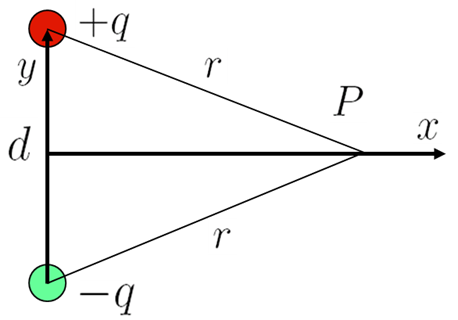

image

The magnitude of the field at point $P$ is given by

$$\label{eq:fieldatP}
E = \frac{1}{4 \pi \epsilon_0} \frac{qd}{\left( x^2 + \left( \frac{d}{2}
\right)^2 \right)^{\frac{3}{2}}}$$

and it is in the $-\hat{\j}$ (or $-\hat{\y}$) direction.

### Electric dipole moment

*Definition:* The electric dipole moment, $\p$, is the product of the charge and the vector displacement from the negative charge to the positive charge in a dipole.

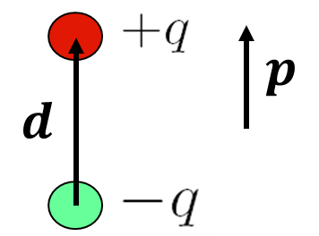

image

$$\p = q \mathbf{d}$$

The electric field of the dipole (Equation
$$eq:fieldatP$$
) can therefore be expressed (as a vector) in terms of the dipole moment, as follows:

$$\label{eq:fieldatP}
\E = \frac{1}{4 \pi \epsilon_0} \frac{\p}{\left( x^2 + \left(
\frac{d}{2} \right)^2 \right)^{\frac{3}{2}}}$$

In the limit of $x \gg d$ (in other words, when we are at a distance $x$ from the dipole that is much larger than the size of the dipole $d$) the electric field due to the dipole can be reduced to:

$$\E = \frac{1}{4\pi \epsilon_0}
\frac{\p}{x^3}$$

### Dipoles in external electric fields

Consider a dipole in a uniform electric field. The force on each charge has magnitude $qE$, but since these forces are in opposite directions there is no net force on the dipole. There is, however a torque about the centre of the dipole.

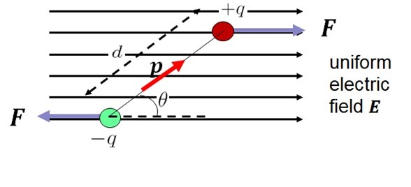

image

The torque about the centre of the dipole is

$$\begin{aligned}
\tau = 2 F \frac{d}{2} \sin\theta = q E d \sin\theta = |p|E \sin\theta
\end{aligned}$$

The direction of the torque is perpendicular to the page, so it can be represented in vector form as $\boldsymbol{\tau} = \p \times \E$.

The torque will cause the dipole to rotate and align itself with the electric field as shown here:

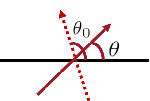

We can use the work done by the field to determine what is the minimum energy configuration (although it should be fairly obvious). The work done is the integral of the product of the torque and the angle turned through:

$$\begin{aligned}
W &= \int_{\theta_0}^{\theta} |\tau| \d\theta \\
&= \int_{\theta_0}^{\theta} pE \sin\theta \d\theta \\
&= [-pE \cos\theta]_{\theta_0}^{\theta}
\end{aligned}$$

The change in potential energy is $\Delta U = W$, hence:
$$\begin{aligned}
\Delta U = U(\theta_0) - U(\theta) = pE(\cos\theta_0 - cos\theta)
\end{aligned}$$

The zero of potential energy $U(\theta_0)$ can be chosen to be anywhere, so we can choose it to correspond to $\theta_0 = 90^{\circ}$ in which case $U = -pE \cos\theta$. This energy can be expressed in vector form as $U = - \p \cdot \E$.

Not surprisingly, the energy is a minimum when the dipole is aligned with the field at which point the torque will be zero.

## Continuous charge distributions

*Recommended reading:* Tipler & Mosca Chapter 22

Charges are discrete i.e. all charges sit on point like particles but if we have a large number of changes they can be treated as a continuous charge distribution. Continuous charge distributions can be described by linear, surface or volume charge densities. To use Coulomb’s Law to calculate the electric field in these cases you may need to integrate using the charge density.

## Electric flux & Gauss’s Law

Flux has been found to be a concept that’s often misunderstood when discussing electric fields.

But in the case of the electric field from static charges nothing is “flowing”. You can think of it as the number of field lines passing through a unit of area. Alternatively consider an analogy of a light source – a source of photons.

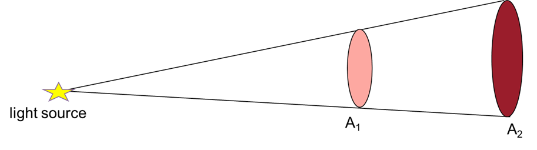

Since photons travel in straight lines, the number of photons passing through area $A_1$ in unit time is the same as that passing through area $A_2$, i.e. the flux of photons is the same, $I_1 A_1 = I_2 A_2$ – where $I_{1,2}$ is photon intensity. The intensity of photons is proportional to $\frac{1}{A} \propto \frac{1}{r^2}$ so the photon field depends on $\frac{1}{r^2}$. Replace the light source with a source of electric field e.g. a point charge. The field starts at the point charge and spreads out. The amount of field doesn’t increase as we move away from the charge because there is no source of electric field.

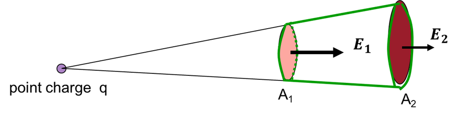

Consider the field in and out of the volume enclosed between the two areas (a truncated cone). The total field in and out is the surface integral of the component of the field normal to the surfaces. On the curved faces, the normal component of $\E$ is zero. On the spherical faces, $A_1$ and $A_2$, the field is normal. If flux into the volume is negative, and flux out is positive $\E$ decreases with $\frac{1}{r^2}$ and the area increases with $r^2$. So the fluxes through the two faces, $A_1$ and $A_2$, are **equal** and **opposite**.

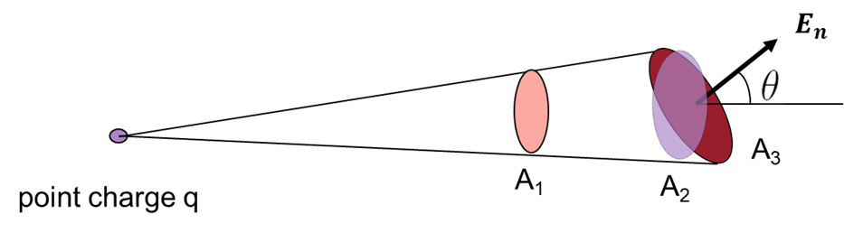

If a surface is tilted at an angle $\theta$ the field normal to the surface is $\E_n = \E \cos\theta$. To determine the flux through the surface we need $\oiint E \cos\theta \d A$, where the integral is over the surface. We can see that this flux is still the same as that through $A_1$ and $A_2$ because all the flux that impinges on $A_2$ also impinges on $A_3$.

Consider a spherical surface with a point charge $q$ at the centre:

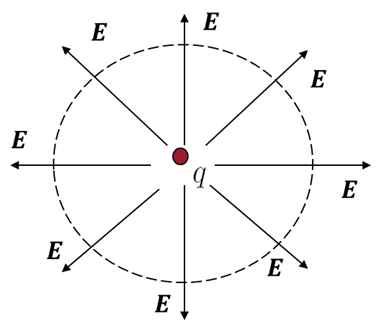

The net flux is non-zero as $\E$ is pointing outwards over the whole spherical surface. Because of the symmetry the magnitude of $\E$ is consistent across the surface and $\E$ is always perpendicular to the surface.

Total flux of $\E$ is $\Phi_{\E} = E_n \times Area$. Therefore
$$\begin{aligned}
\Phi_E = \frac{q}{4\pi\epsilon_0 r^2} \times 4\pi r^2 =
\frac{q}{\epsilon_0}
\end{aligned}$$

**This result is independent of the radius of the sphere – in fact, it is independent of the shape of the surface enclosing the charge.**

## Gauss’s Law

We can calculate the electric field from any charge distribution with Coulomb’s Law. Gauss’ Law in the integral form which we’ll use here can calculate fields in some highly symmetric cases. Gauss’ Law states that for any **closed surface** $S$:

$$\begin{aligned}
\oiint{E_n} \d \S = 0 \quad \text{if no charge is enclosed}
\end{aligned}$$

and

$$\begin{aligned}
\oiint{E_n} \d \S &= \frac{q}{\epsilon_0} \quad \text{if charge} \;
q \; \mathrm{is enclosed}
\end{aligned}$$

Or in words: the magnitude of the electric field normal to the surface integrated over the whole of the surface is equal to the charge enclosed divided by $\epsilon_0$.

More generally, the integral form of Gauss’s Law is
$$\label{eq:GaussLaw}
\oiint \E \cdot \d \S =\frac{Q}{\epsilon_0}$$

$\d \S$ is a vector normal to the surface with magnitude equal to the size of an element of area. $\E \cdot \d \S$, which is a scalar product, extracts the component of the electric field normal to the surface and multiplies it by the size of an element of the area. $Q$ is the total charge enclosed within $S$, where $Q = \sum_i q_i$ where the sum runs over all charges inside $S$ (where $S$ is a closed surface enclosing a volume $V$).

- Field due to a line of charge, linear charge density $\lambda$ C/m
- Field due to an infinite plane of charge, surface charge density $\sigma$ C/m$^2$
- Field due to a solid sphere of uniformly distributed charge $Q$

### Field inside a hollow object

Consider a spherical shell with charge $Q$. By symmetry, the field is radial in all directions.

Applying Gauss’s Law with a spherical Gaussian surface **outside** the shell, as shown in , gives:
$$\begin{aligned}
E_r = \frac{Q}{4\pi\epsilon_0 r^2}
\end{aligned}$$

i.e. the same as point charge or a solid sphere of charge.

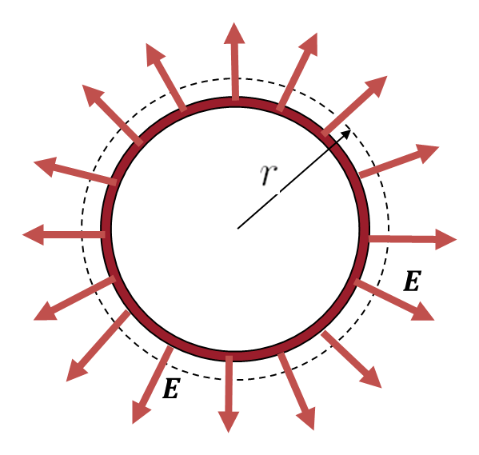

image

Applying Gauss’s Law with a spherical Gaussian surface inside the shell gives $E_r = 0$ because there is no charge inside the surface.

**There is no electric field inside a uniform shell of charge.**

In a conductor, charges are free to move and as like charges repel excess charge will move to the outside surface of an isolated conductor.

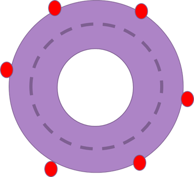

image

Consider a Gaussian surface just inside a conductor as shown in . The electric field is zero everywhere inside the conductor – because all the charges are on the outside. The flux through the Gaussian surface must therefore be zero.

This applies if there is a cavity inside the conductor and so inside any cavity in a conductor, the electric field is zero. This principle is used to build Faraday Cages to shield sensitive electronics.

The field at the surface of a conductor is always perpendicular to the surface. If this wasn’t the case, there would be a component of the field tangential to the surface. The charges in the conductor would move across the surface under the influence of the tangential component of the field until that component was zero. Therefore the field is always perpendicular to the surface.

## Electric potential

The electric potential due to a positive charge is positive. The electric potential due to a negative charge is negative The potential difference between two points, $a$ and $b$, is

$$\begin{aligned}
\Delta V = V_b - V_a =\frac{(U_b - U_a)}{q_0}
\end{aligned}$$

The electric (or electrostatic) potential, often just called potential, is defined as the potential energy per unit (test) charge.

Consider bringing an infinitesimal test charge ($q_0$) from infinity into a region containing a system of charges. If $U$ is the final potential energy of the charge the electric potential is given by $V = U/q_0$.

The change in potential energy in going from point $a$ to point $b$ is given by the integral along the path from $a$ to $b$ of the work done on the charge:

$$\begin{aligned}
\Delta U = - W_{ab} = -\int_a^b \F \cdot \d\l = -q_0 \int_a^b \E \cdot
\d\l
\end{aligned}$$

We know that
$$\begin{aligned}
\frac{\Delta U}{q_0} &= V_b - V_a
\end{aligned}$$

hence

$$\begin{aligned}
\Delta V_{ab} &= -\int_a^b \E \cdot \d\l
\end{aligned}$$

So the change in electrical potential is the line integral of the electric field along the path from $a$ to $b$. We can choose the reference point of the potential to be where we like but normally select infinity. So

$$\begin{aligned}
V_b = -\int_\infty^b \E \cdot \d\l
\end{aligned}$$

The potential at a distance $r$ from a point charge is

$$\begin{aligned}
V(r) &= -\int_\infty^r \frac{1}{4\pi\epsilon_0} \frac{q}{r^2} \d r
\\
&= \frac{q}{4\pi\epsilon_0} \left[ \frac{1}{r} -
\frac{1}{\infty} \right] \\
&= \frac{q}{4\pi\epsilon_0} \frac{1}{r}
\end{aligned}$$

**Note:** The dependence of the potential for a point charge on distance is $\frac{1}{r}$ and the force depends on $\frac{1}{r^2}$ because the electric field is the gradient of the potential.

# Magnetic Fields

## The magnetic field

*Recommended reading:* Tipler & Mosca 26

In electrostatics, we viewed electric charges as interacting via the electric field to avoid action at a distance. The field surrounds any charge and when a second charge is brought near to the first it interacts with the field that is already present.

Can we think of “magnetic charges" interacting via the magnetic field, $\B$? **No.** This is because magnetic charges have not been found to exist - there is no evidence for single North or South poles. Searches have been made for magnetic monopoles, but without any success, although their existence has not been entirely ruled out. (This is way beyond our syllabus but if you are interested you could try looking at https://royalsocietypublishing.org/doi/10.1098/rsta.2018.0328.)

The magnetic field is produced by *moving* electric charges (i.e. electric currents). As with the electric field, the magnetic field can be represented using field lines and the density of field lines represents the strength of the field and the direction is that in which a north pole would move.

The magnetic field $\B$ is measured in the SI unit of Tesla or in Gauss: 1 Tesla = $10^4$ Gauss = $\frac{\mathrm{Ns}}{\mathrm{Cm}} = \frac{\mathrm{N}}{\mathrm{Am}}$.

There are some important differences between the behaviour of charges in electric and magnetic fields. In electric fields, the force on a charge is parallel to the field lines – a positive charge moves along the field lines in the direction indicated. In magnetic fields, the force on a *moving* charge is perpendicular to the field lines.

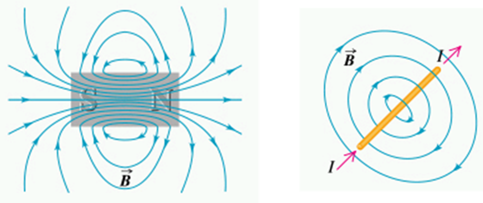

image

Magnetic field lines always form closed loops whereas electric field lines begin and end on charges. This means that a version of Gauss’ Law for magnetism states $\Phi_B = \oiint \B \cdot \d\s = 0$ (see Tipler & Mosca, 27-3). As field lines are closed all field lines entering a closed surface must leave it as well. So net magnetic flux through the surface is zero.

The direction of the magnetic field direction due to an electric current is given by the right-hand rule. If you point the thumb of your right hand in the direction of the current and then curl the fingers the field is in the direction of the curl of your fingers.

## Forces from Magnetic Fields

*Recommended reading:* Tipler & Mosca 26-2

The Lorentz force describes the force felt by a moving charge in a combination of electric and magnetic fields.

$$\F = q(\E + \v \times \B)$$

The cross product tells us that force due to the magnetic field $\B$ is perpendicular to the magnetic field and the velocity of a charged particle ($\v$) and therefore when the velocity and magnetic field are parallel (or antiparallel) to each other, the force on the charged particle due to the magnetic field is zero. Since the magnetic force, is always perpendicular to the velocity vector of the particle it cannot do any work on the charge and therefore cannot change the energy and speed of the particle.

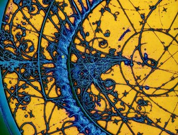

image

The artistically enhanced image in was produced by the Big European Bubble Chamber (BEBC), which started up at CERN in 1973. Charged particles passing through a chamber filled with hydrogen-neon liquid leave bubbles along their paths (Image: BEBC). You can see the spiral paths of the charged particles as they move in circles under the influence of the magnetic field but lose energy through collisions with the Hydrogen-neon atoms.

### Circulating charges

*Recommended reading:* Tipler & Mosca 26-2

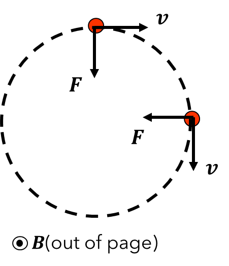

image

If $\B$ and $\v$ are perpendicular, a particle moving in a constant $\B$ field is forced to move in a circle by the (centripetal) magnetic force. Note that if there is a component of $v$ in the same direction as $\B$ there is no force in this direction and that component of the velocity is unchanged in direction or magnitude causing the particle to move in a spiral. The frequency of rotation around the circle is the cyclotron frequency. This frequency does not depend on the particle velocity or the radius of the circle.

Charged particles will tend to spiral along field lines. By shaping the magnetic field lines as shown in , it is possible to confine charged particles inside a “magnetic bottle".

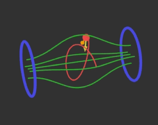

image

Charged particles are also confined along the Earth’s field lines. This protects us from cosmic radiation and is also responsible for the northern and southern lights.

### Magnetic force on a wire

We can use the expression for the force on a single charge due to a magnetic field to calculate the force on a length of wire carrying a current. This arguments is describe below but you can also look at the derivation in Tipler & Mosca (26-1).

The expression for the force on a moving charge in a current carrying conductor in a magnetic field is $\F = q\v_d \times \B$ (where $\v_d$ is the drift velocity for the charge carriers). The current is the rate at which charge passes any point on the wire and this is just $nqv_d$ where $n$ is the number of charge carriers per unit length. Note that if the carriers are positive then the vector $qv_d$ points in the direction of conventional current flow. If $q$ is negative $v_d$ points in a direction opposite to conventional current flow but the combination $qv_d$ points in the direction of conventional current flow. The force per unit length on the wire is $nq \v_d \times \B$ and the force on a length $L$ of wire is $Lnq \v_d \times \B$. We define $\L$ as the vector length of the wire i.e. a vector with length equal to the length of the wire and in the direction of the flow of conventional current. $\L$ therefore points in the direction of $q \v_d$ so $\L \times \B$ is in the direction of the force on the wire and, since $I = nq v_d$, the force is given by $\F = I \L \times \B$.

### Force on current loops & motors

*Recommended reading:* Tipler & Mosca 26-3

The force on a current carrying conductor in a magnetic field $\F = I \L \times \B$ can be used to make a motor. The principle of operation of a motor made of a single loop of wire is shown nicely in http://www.walter-fendt.de/html5/phen/electricmotor_en.htm.

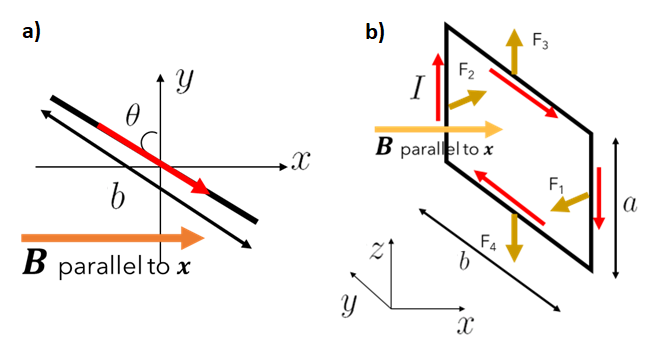

image

### Torque on a coil

For a single loop the torque is $\Gamma = BIab \sin\theta$, noting that $ab$ is the area of the loop. If instead of a single loop there is a coil with $N$ loops then the torque is simply multiplied by $N$, hence $\Gamma = NBIab \sin\theta$. By analogy with the electric dipole, we can define a magnetic dipole moment $\boldsymbol{\mu} = IA \hat{\n}$, where $\hat{\n}$ is a unit vector in the direction normal to the area $A$. So we can express the torque as $\Gamma = \boldsymbol{\mu} \times \B$.

## The Biot-Savart Law

*Recommended reading:* Tipler & Mosca 27-1, 27-2

We can generalize our previous result for the force on a current $F = IL \times B$ by considering a small element of current $dF = I \d s \times B$ and then calculate the field due to a sum of current elements where these do not necessarily lie on a straight line or other simple shape. The magnetic field could have been produced by another current which give us interactions between currents.

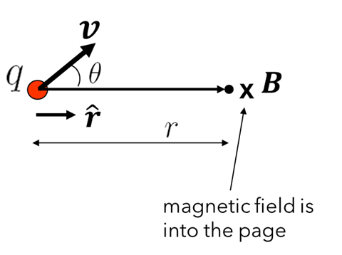

image

A point charge, $q$ ,moving with velocity, $v$, produces a magnetic field $B$ at a distance $r$ in a direction given by $\v \times \hat{\r}$, where $\hat{\r}$ points from $q$ to the point where the field is measured.

$$\begin{aligned}
\B = \frac{\mu_0}{4\pi} q \v \times \frac{\hat{\r}}{r^2}
\end{aligned}$$

The magnetic field at point $P$ due to the current element $I \d\s$ is therefore
$$\begin{aligned}
\d \B = \mu_0/4\pi I \d\s \times \r /r^2
\end{aligned}$$

or, in terms of the magnitudes,
$$\begin{aligned}
\d \B = \frac{\mu_0}{4\pi} \frac{I \d s \sin\theta}{r^2}
\end{aligned}$$

This is the **Biot-Savart Law**, which is analogous to Coulomb’s Law for evaluating the electric field due to a point charge. The Biot-Savart Law can be used to calculate the field due to a set of conductors.

## Ampère’s Law

*Recommended reading:* Tipler & Mosca 27-4

Ampère’s Law states that the sum (or integral) of the product $\B \cdot \d\s$ around a closed loop is equal to the total current flowing through the surface enclosed by the loop multiplied by the permeability of free space, $\mu_0$. Mathematically,
$$\begin{aligned}
\oint \B \cdot \d \s = \mu_0 I
\end{aligned}$$

where $\d\s$ is a vector that points along the tangent to the loop with a magnitude equal to a small length of the curve.

To use Ampère’s law we construct an imaginary Ampèrian loop around some current carrying conductors. (Compare this to constructing a Gaussian surface around charges to determine the electric flux and hence the field.) In this case the loop is arranged so it is parallel to or perpendicular to the magnetic field so $\B \cdot \d\s =|\B||\d\s|$ or $\B\cdot \d\s = 0$ respectively.

We will solve symmetric problems in this way as there are limitations to Ampère’s law (discussed in Tipler & Mosca 27-4). We evaluate the line integral of $\B$ around the loop which is equal to the sum of the current flowing through the loop. (Compare with Gauss’s Law where the integral of $\E$ over a surface was equal to the charge enclosed by the surface.)

We’ll consider a couple of classic examples of using Ampère’s Law:

- A single wire carrying current
- The magnetic field of a solenoid

### Example: Magnetic field of a wire

Consider the field outside a single wire carrying current and determine the field at a distance $R$ from the wire. From the symmetry of the problem the field lines are circular about the wire and the field has a constant magnitude at a constant distance from the wire. So we pick a loop that is also circular. The magnitude of $\B$ is constant along the loop and the loop is always parallel to $\B$.

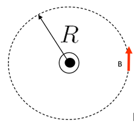

image

$$\begin{aligned}
\oint \B \cdot \d\s = B \times 2\pi r = \mu_0 I
\end{aligned}$$

Rearranging gives
$$B = \frac{\mu_0
I}{2\pi R}$$

as for Biot-Savart Law – as we would expect.

### Example: Magnetic field of a solenoid

A solenoid is a wire wound in a long straight helix with the length usually much longer than the diameter. It looks like a set of coils next to each other and the overall field is the same as a for a bar magnet of the same shape.

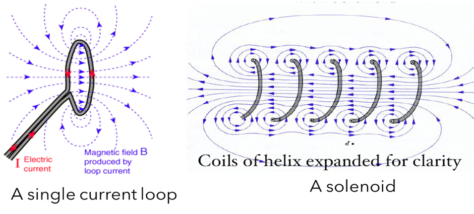

image

In this example we calculate the magnetic field of a long solenoid with $n$ turns per unit length. As the length tends to infinity, the field outside tends to zero and the field inside becomes increasingly uniform and parallel to the axis. We need to find a suitable Ampèrian loop (). In this case we pick a rectangular loop where one side (a-b) lies within the solenoid and is parallel to the field. One side (c-d) is outside the solenoid where the field is 0. And the two remaining sides are partly perpendicular to the field and partly in a field free region.

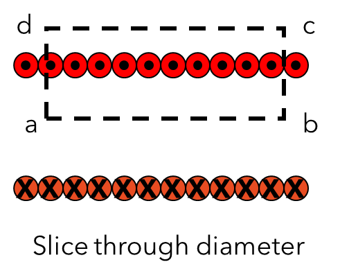

image

The only contribution to $\oint \B \cdot \d\s$ from the loop is the side ab where, in this case, the field is parallel to the path. Since $\B$ is uniform along the path $\oint \B \cdot \d\s = BL$ where $L$ is the length of the path from a to b.

The total current enclosed by the loop is the number of turns per unit length in the solenoid multiplied by the current, $nIL$.
$$\begin{aligned}
\therefore \oint \B \cdot \d\s = BL = \mu_0 nIL \\
\therefore B = \mu_0 nI
\end{aligned}$$

## Faraday’s Law of induction

A changing magnetic flux in a circuit will produce a current that opposes that change. Faraday’s Law of induction relates the induced EMF in a circuit to the rate of change of magnetic flux through a circuit.

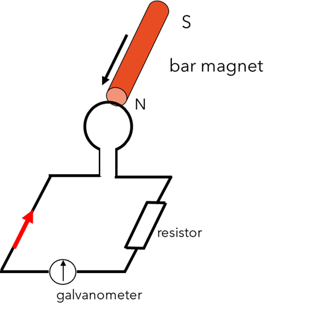

image

Consider the case of the circuit shown in that has a loop of wire.

- If the magnet is stationary: no current flows
- If the magnet moves towards the coil : current flows while the motion continues.
- If the magnet moves away from the coil : the current flows in opposite direction
- If a north pole is replaced by a south pole, then the current flow reverses in direction.
- If the magnet moves faster the current is increased.

The induced current is a result of an induced electromotive force (emf), which depends on the rate of change of magnetic flux through the loop. We have already discussed electric flux in Gauss’ Law and we’re using the same idea here for Faraday’s Law of induction. The changing flux through the circuit could be due to a magnetic field produced by a second circuit.

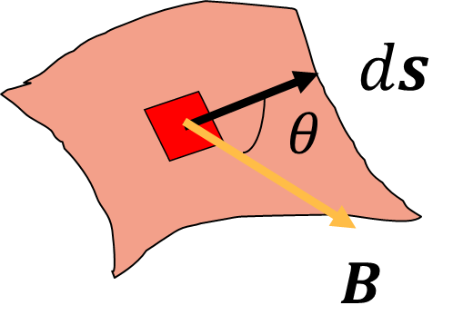

image

The magnetic flux through a surface is the component of the field perpendicular to the surface multiplied by the area of the surface. Mathematically

$$\begin{aligned}
\Phi_B = \int\B \cdot \d\s \\
\text{or} \; \Phi_B = \int \B \cos\theta \d s
\end{aligned}$$

where, as with Gauss’s Law, $\d \s$ is a vector perpendicular to the surface and with magnitude equal to the area of an element of the surface. We take the dot product to extract the component of $\B$ perpendicular to the surface. Magnetic flux is measured in Webers (Wb). You can see that this must be equivalent to T m$^2$ and, less obviously, Vs.

Faraday’s Law states that the induced emf in a circuit is equal to the negative of the rate of change of flux through the circuit, written as

$$\begin{aligned}
V = - \frac{\d \Phi_B}{\d t}
\end{aligned}$$

If rather than a single loop of wire a coil has $N$ turns close together then the induced emf is simply multiplied by $N$.

### Transformers

There are a number of devices that use inductance to useful effect. Transformers are one such device.

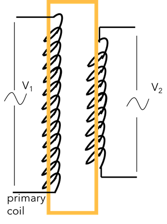

image

Transformers (see ) consist of two or more coils (usually with a ferromagnetic core) so that the field from one coil is coupled to the other coil. An AC voltage applied to the primary coil ($V_1$) is transformed to a different voltage at the secondary coil ($V_2$).

$$\begin{aligned}
\frac{V_2}{V_1} = \frac{N_2}{N_1}
\end{aligned}$$

where $N_1$ and $N_2$ are the number of turns in the primary and secondary coils, respectively.

If $N_2 > N_1$, then the output voltage from the secondary coil can be much larger than the voltage in the primary coil and this can be used to produce very high voltages for example, for an extra high tension (EHT) supply. If $N_2 < N_1$, then the output voltage from the secondary coil is smaller but the output current can be very large for use in high current applications such as welding power supplies.

### Dynamo

A dynamo is a type of generator, where a generator refers to a device that turns mechanical motion into electrical energy.

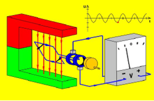

image

is taken from http://www.walter-fendt.de/html5/phen/generator_en.htm, an app which allows you to simulate a generator by changing certain parameters.

The dynamo functions as the opposite of a motor. In a motor a current applied to a coil in a magnetic field generates kinetic energy. In a dynamo the rotation of a coil in a magnetic field generates an alternating current.